# Reproducible Research: Peer Assessment 1

AnneLawrence

## Loading and preprocessing the data

```r
#Loading the data and converting date to date form

activity <- read.csv("activity.csv")

activity$date<- as.Date(activity$date, "%d/%m/%Y")
```

## What is the mean total number of steps taken per day?

1. Calculate the total number of steps taken per day.

```r
total_steps_per_day <- tapply (activity$steps, activity$date,
                               sum,
                               na.rm=TRUE)
```

2. Make a histogram of the total number of steps taken each day

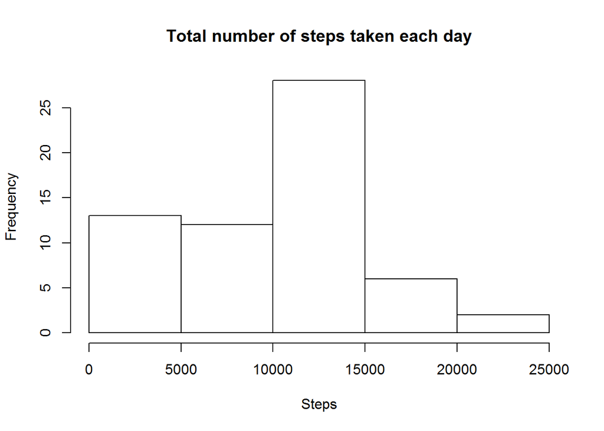

```r
hist(total_steps_per_day,
     main = 'Total number of steps taken each day',
     xlab= 'Steps')
```

3.Calculate and report the mean and median of the total number of steps taken per day

```r
mean_total_steps_per_day <- round(mean(total_steps_per_day),digits = 3)

median_total_steps_per_day <- median(total_steps_per_day)
```

Mean of the total number of steps taken per day is 9354.23 (2dp).

Median of the total number of steps taken per day is 10395.

## What is the average daily activity pattern?

1.Make a time series plot (i.e. type = “l”) of the 5-minute interval (x-axis) and the average number of steps taken, averaged across all days (y-axis).

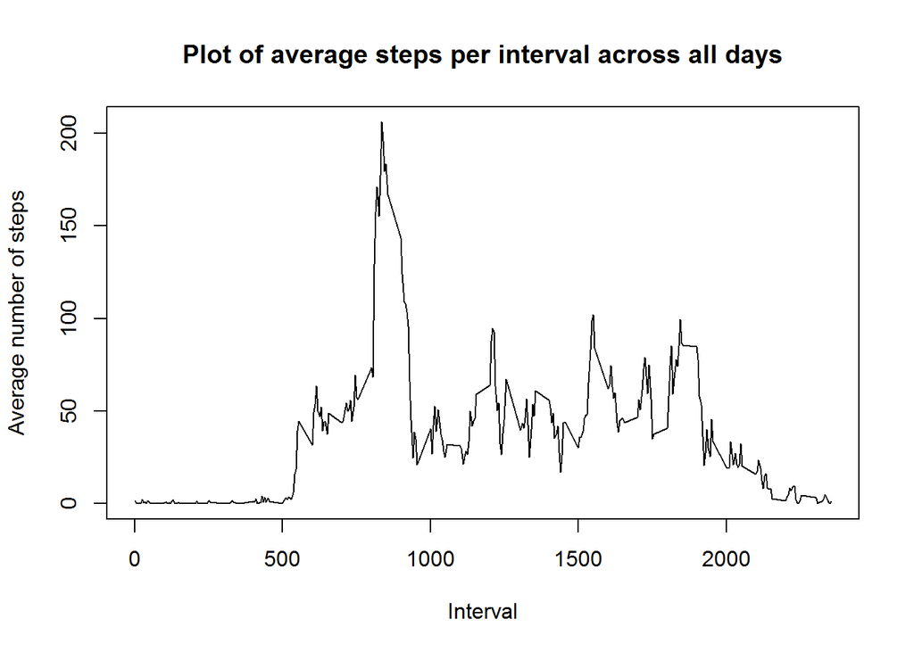

```r
average_steps_per_interval <- tapply (activity$steps, activity$interval,
                                      mean,
                                      na.rm=TRUE)

intervals <- activity$interval[1:288]

plot (intervals, average_steps_per_interval,
      type = "l",
      xlab = "Interval",
      ylab = 'Average number of steps',
      main = "Plot of average steps per interval across all days"  )
```

2. Which 5-minute interval, on average across all the days in the dataset, contains the maximum number of steps?

```r
max <- max(average_steps_per_interval)

m <- which (average_steps_per_interval == max(average_steps_per_interval)  )

max.int <- names(m)
```

The interval which, on average across all the days in the dataset, contains the maximum number of steps is interval 835.